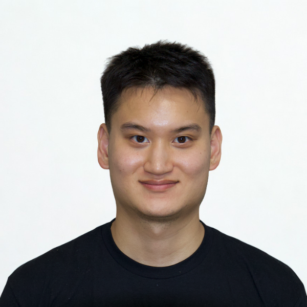

# Jeffrey Hsu

MS in Digital Marketing | Marketing Analytics and Strategy

I am currently pursuing a **Master of Science in Digital Marketing** at **Cal Poly Pomona**, where I am building skills in marketing analytics, dashboards, digital strategy, and data storytelling.

## Career Aspirations

My goal is to build a career in **marketing analytics and digital strategy**, where I can combine data analysis with business decision-making. I am particularly interested in roles that involve performance marketing, content strategy, and data-driven optimization.

I want to work in an environment where I can: - Analyze marketing performance data to drive decisions  
- Build dashboards and reports that influence strategy  
- Use tools like R, Quarto, and analytics platforms to improve business outcomes

## Skills

### Marketing & Analytics

- KPI analysis and performance tracking
- Content and social media analysis
- Campaign evaluation and optimization

### Technical Skills

- R programming (data cleaning, modeling, visualization)
- Quarto (dashboards and website publishing)
- Data visualization and reporting

### Communication

- Translating data into actionable insights
- Presenting findings to non-technical audiences
- Structuring analysis into clear business narratives

## Education

**California State Polytechnic University, Pomona**  
Master of Science in Digital Marketing

## Experience

Through my coursework and projects, I have developed experience creating dashboards, analyzing content performance, and presenting insights in a professional format.

[GitHub](https://github.com/hsujeffrey) [LinkedIn](https://www.linkedin.com/)